# Отчёт по лабораторной работе №1 по дисциплине “Статистическое моделирование”

Шайхльбарин Денис Маратович

Выполнено: 2024-03-11

```r
library(moments)
library(ggplot2)
z<-read.csv(file = "cisc.csv",  header = TRUE);
year<-z$Year
frequency<-z$Frequency
```

```r
year
```

```
##  [1] 2023 2022 2012 2011 2010 2007 2006 2005 2004 2003 2002 2001 2000 1999 1998
## [16] 1997 1996
```

```r
frequency
```

```
##  [1] 9043.92 9008.82 8794.33 8709.06 8242.45 8220.10 7657.60 7638.60 6315.20
## [10] 5255.00 4588.49 3391.12 2205.56 1286.30  743.40  375.00  266.00
```

## Зависимость рекордной частоты ядра процессора на архитектуре CISC по годам:

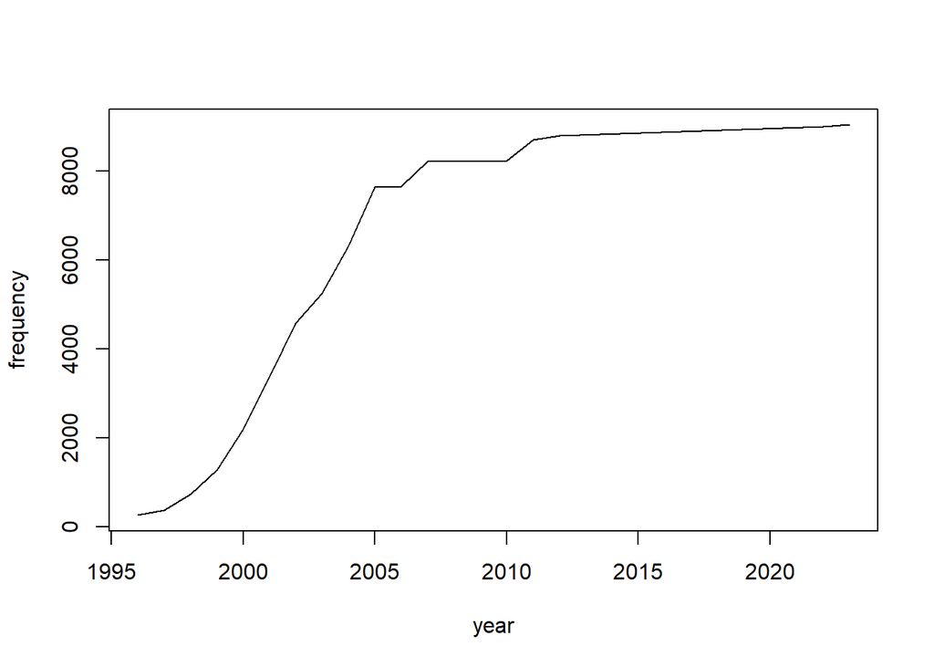

```r
plot(year, frequency, type='l')
```

Ссылка на исходные данные - https://skatterbencher.com/cpu-overclocking-world-record-history/

Среднее

```r
mean(frequency)
```

```
## [1] 5396.526
```

Медиана

```r
median(frequency)
```

```
## [1] 6315.2
```

Дисперсия

```r
var(frequency)
```

```
## [1] 11305356
```

Стандартное отклонение

```r
sd(frequency)
```

```
## [1] 3362.344
```

Наименьшее

```r
min(frequency)
```

```
## [1] 266
```

Наибольшее

```r
max(frequency)
```

```
## [1] 9043.92
```

Коэффициент эксцесса

```r
kurtosis(frequency, na.rm = TRUE)
```

```
## [1] 1.551109
```

Коэффициент ассиметрии

```r
skewness(frequency, na.rm = TRUE)
```

```
## [1] -0.3941082
```

Квантили

```r
quantile(frequency)
```

```
##      0%     25%     50%     75%    100%
##  266.00 2205.56 6315.20 8242.45 9043.92
```

## Распределение Фишера:

При малых значениях своих основных параметров (числа степеней свободы) график плотности распределения однозначно ассиметричен. Само по себе распределение сходится к единице. При увеличении значения параметров плавно смещает “купол” вправо, постепенно напоминая нормальное распределение.

## Степени свободы: df1 = 10, df2 = 10

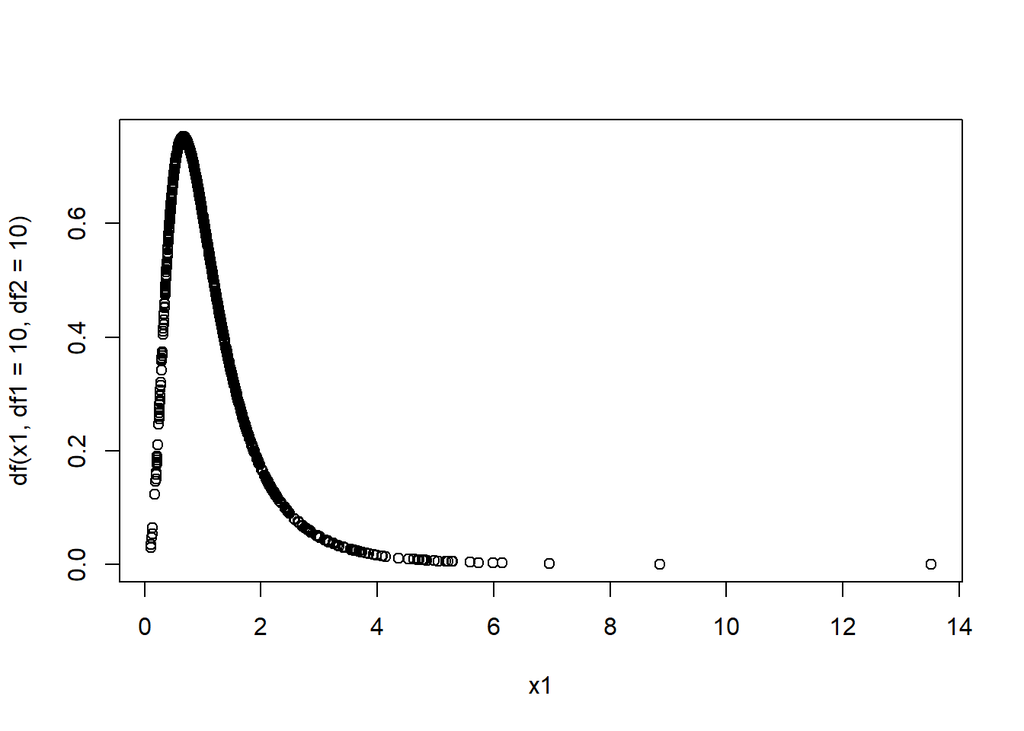

```r
x1<-rf(1000, 10, 10)
plot(x1, df(x1, df1=10, df2=10), type='p')
```

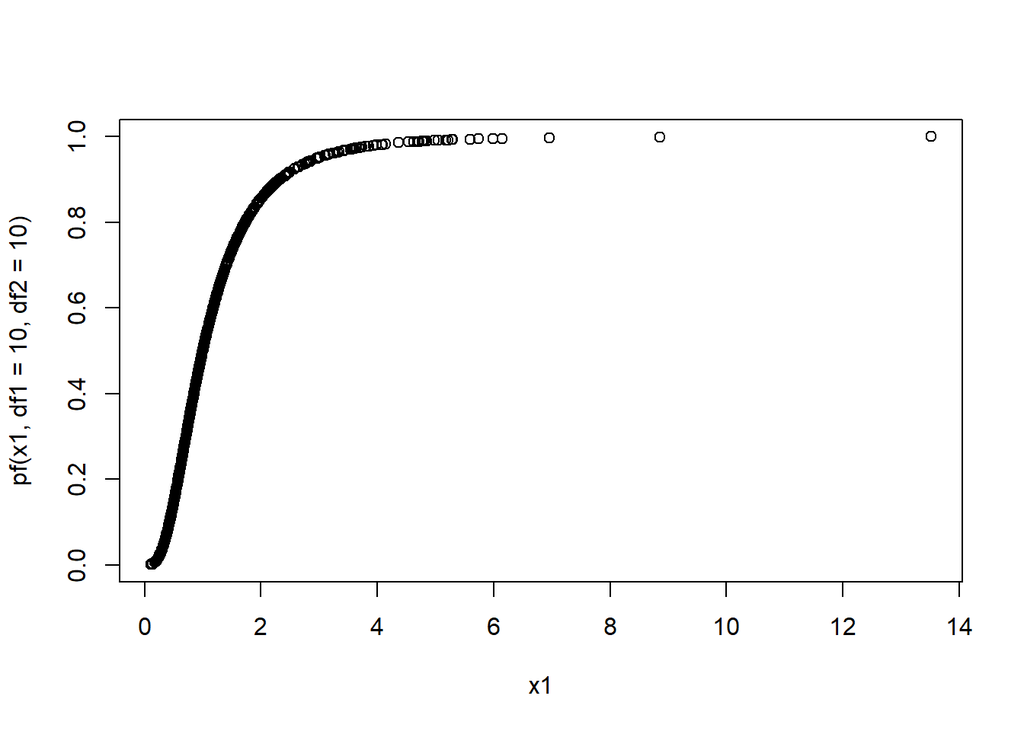

```r
plot(x1, pf(x1, df1=10, df2=10), type='p')
```

Критическое значение:

```r
qf(0.99, 10, 10)
```

```
## [1] 4.849147
```

Уровень доверия:

```r
pf(1.55, 10, 10)
```

```
## [1] 0.7496075
```

## Степени свободы: df1 = 10, df2 = 50

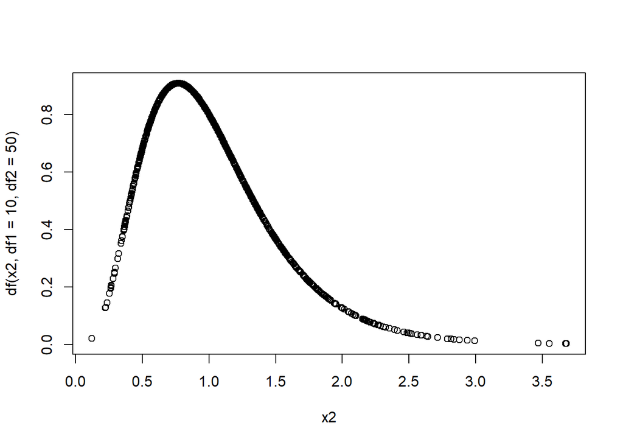

```r
x2<-rf(1000, 10, 50)
plot(x2, df(x2, df1=10, df2=50), type='p')
```

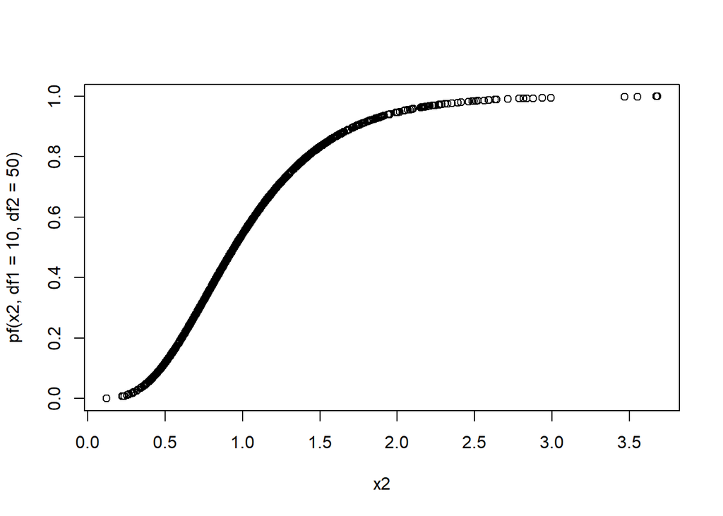

```r
plot(x2, pf(x2, df1=10, df2=50), type='p')
```

Критическое значение:

```r
qf(0.95, 10, 50)
```

```
## [1] 2.026143
```

Уровень доверия:

```r
pf(2.33, 10, 50)
```

```
## [1] 0.9757794
```

## Степени свободы: df1 = 10, df2 = 100

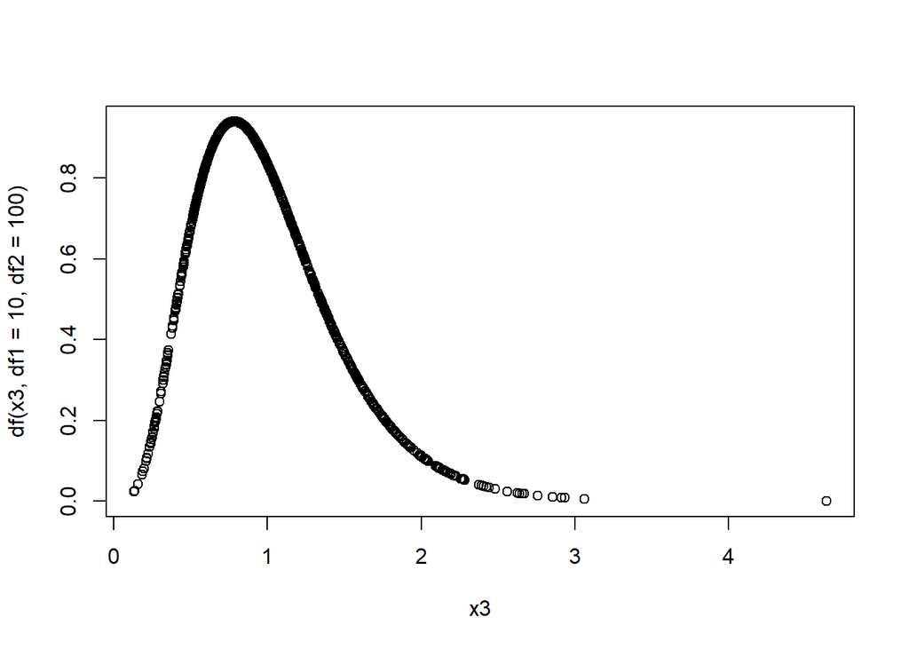

```r
x3<-rf(1000, 10, 100)
plot(x3, df(x3, df1=10, df2=100), type='p')
```

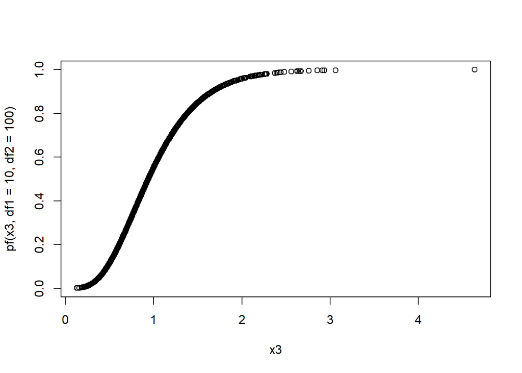

```r
plot(x3, pf(x3, df1=10, df2=100), type='p')
```

Критическое значение:

```r
qf(0.90, 10, 100)
```

```
## [1] 1.663225
```

Уровень доверия:

```r
pf(4.80, 10, 100)
```

```
## [1] 0.9999873
```

## Степени свободы: df1 = 10, df2 = 500

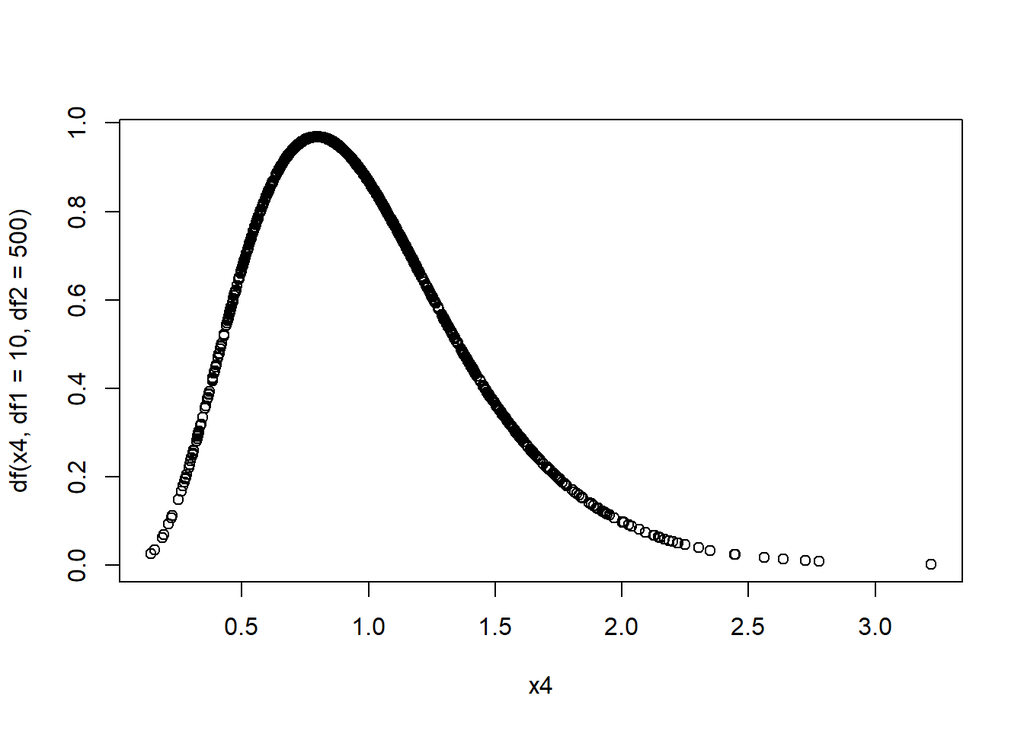

```r
x4<-rf(1000, 10,  500)
plot(x4, df(x4, df1=10, df2=500), type='p')
```

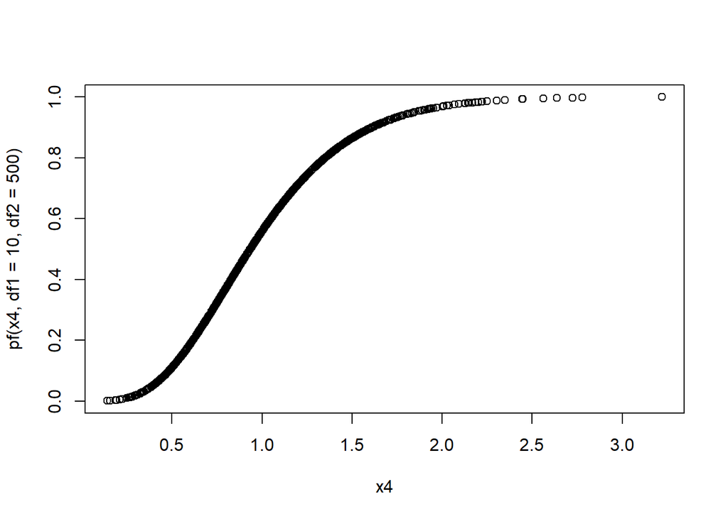

```r
plot(x4, pf(x4, df1=10, df2=500), type='p')
```

Уровень доверия:

```r
pf(1.72, 10, 500)
```

```
## [1] 0.9266348
```

## Степени свободы: df1 = 10, df2 = 1000

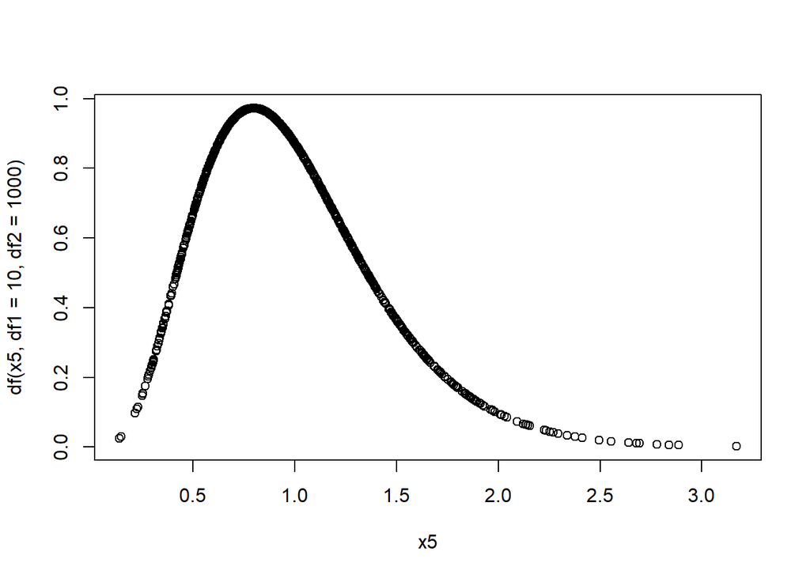

```r
x5<-rf(1000, 10, 1000)
plot(x5, df(x5, df1=10, df2=1000), type='p')
```

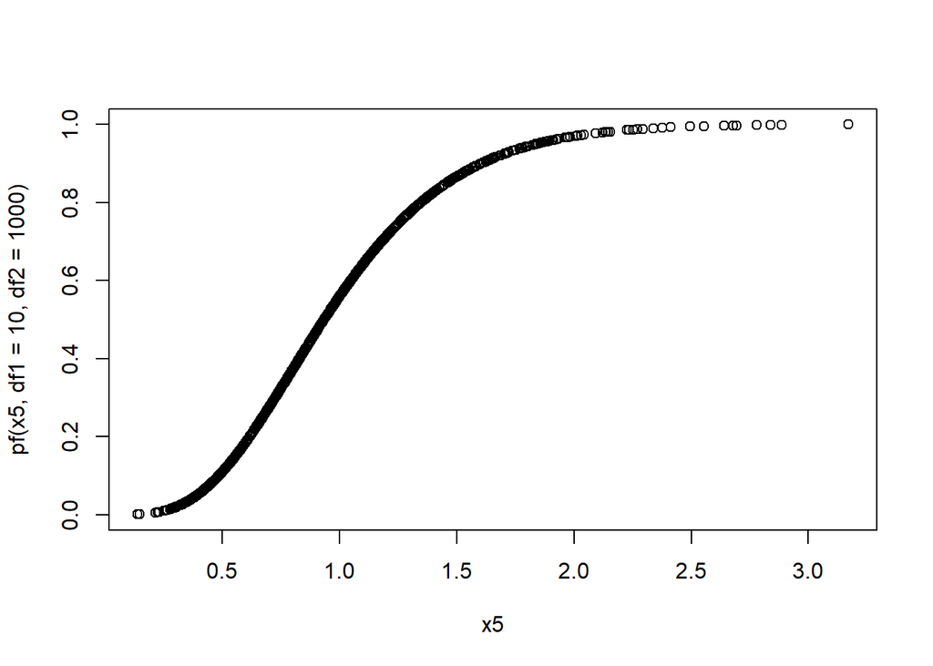

```r
plot(x5, pf(x5, df1=10, df2=1000), type='p')
```

Уровень доверия:

```r
pf(1.35, 10, 1000)
```

```
## [1] 0.8010867
```

## Распределение Стьюдента:

График функции плотности t-распределения симметричен, а его форма напоминает форму купола или шляпы, как у стандартного нормального распределения, но он ниже и шире. При увеличении числа степеней свободы кривая функции плотности всё больше и больше напоминает стандартное нормальное распределение.

## Степень свободы: df = 10

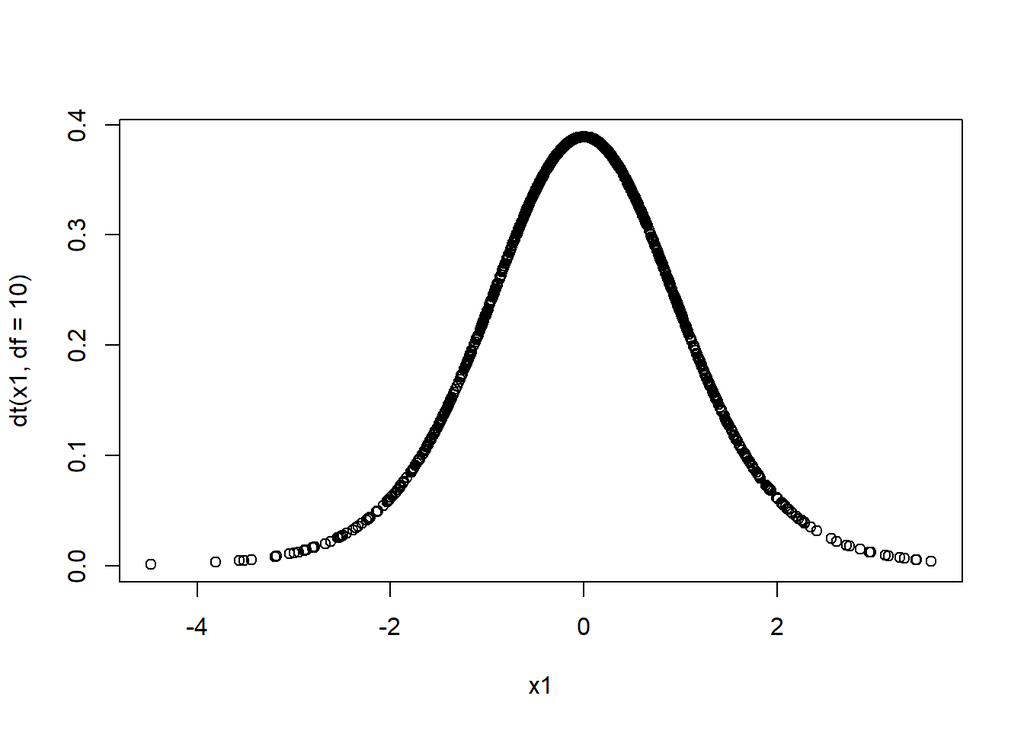

```r
x1<-rt(1000,  10)
plot(x1, dt(x1, df=10), type='p')
```

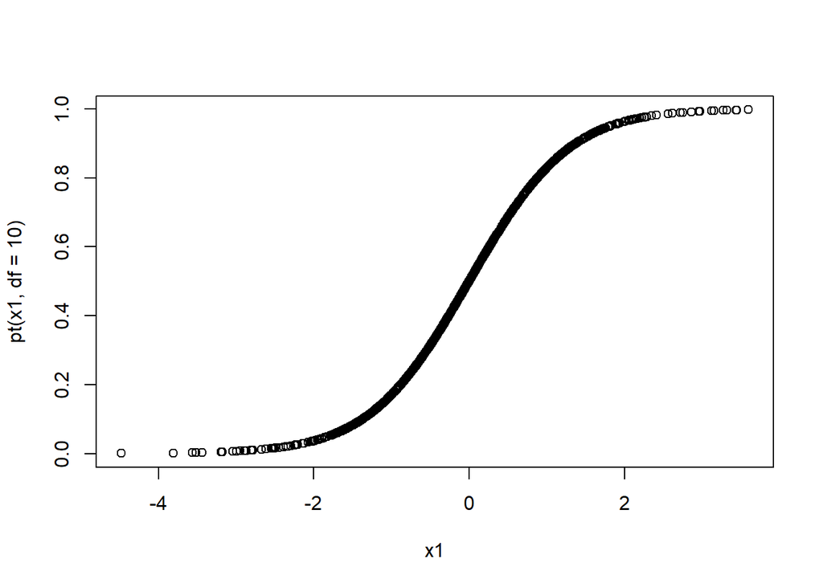

```r
plot(x1, pt(x1, df=10), type='p')
```

Критическое значение:

```r
qt(0.99, 10)
```

```
## [1] 2.763769
```

Уровень доверия:

```r
pt(1.37, 10)
```

```
## [1] 0.8996706
```

## Степень свободы: df = 50

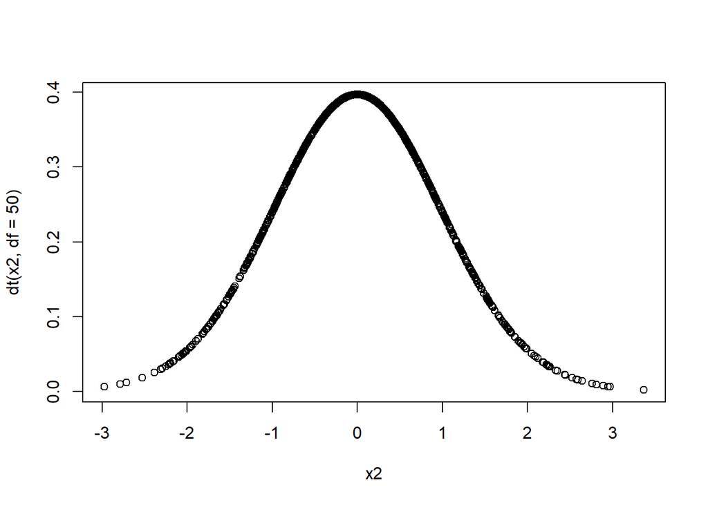

```r
x2<-rt(1000,  50)
plot(x2, dt(x2, df=50), type='p')
```

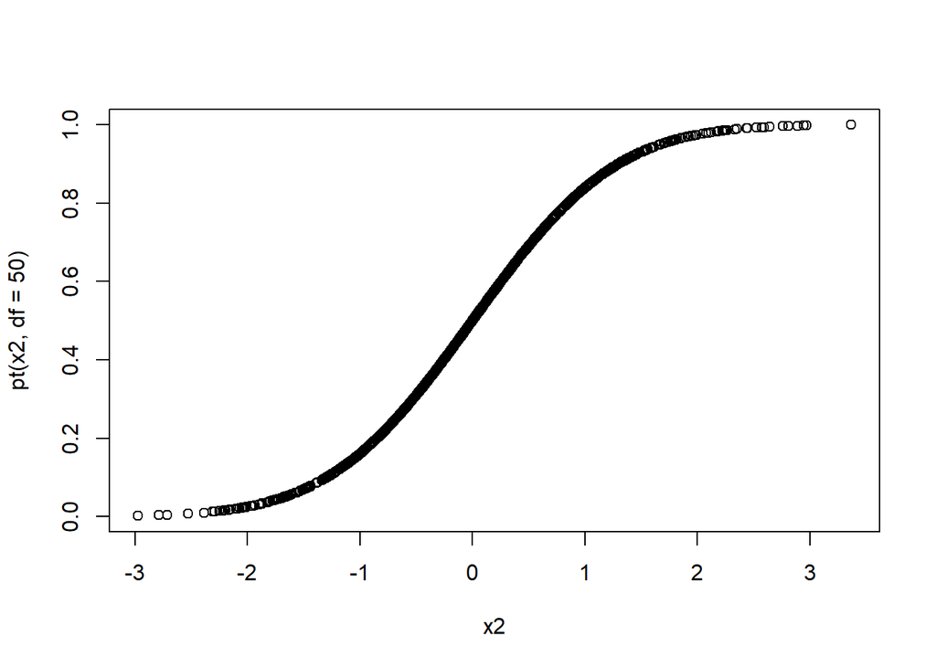

```r
plot(x2, pt(x2, df=50), type='p')
```

Критическое значение:

```r
qt(0.95, 50)
```

```
## [1] 1.675905
```

Уровень доверия:

```r
pt(2.11, 50)
```

```
## [1] 0.9800577
```

## Степень свободы: df = 160

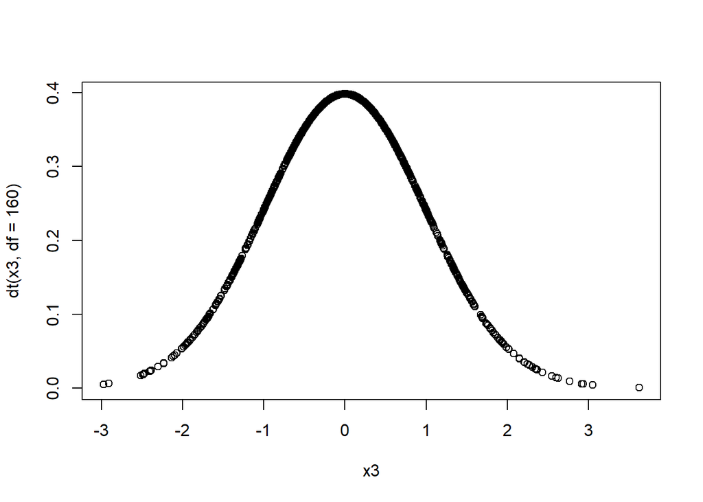

```r
x3<-rt(1000, 160)
plot(x3, dt(x3, df=160), type='p')
```

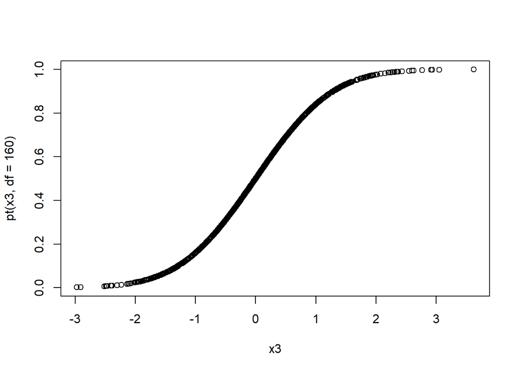

```r
plot(x3, pt(x3, df=160), type='p')
```

Критическое значение:

```r
qt(0.90, 160)
```

```
## [1] 1.286865
```

Уровень доверия:

```r
pt(0.55, 160)
```

```
## [1] 0.7084568
```

## Показательное распределение:

Форма распределения зависит от одного-единственного параметра λ. При его увеличении кривая функции распределения становится более вогнутой вверх-влево, кривая функции плотности - влево-вниз.

## Параметр λ = 0.3

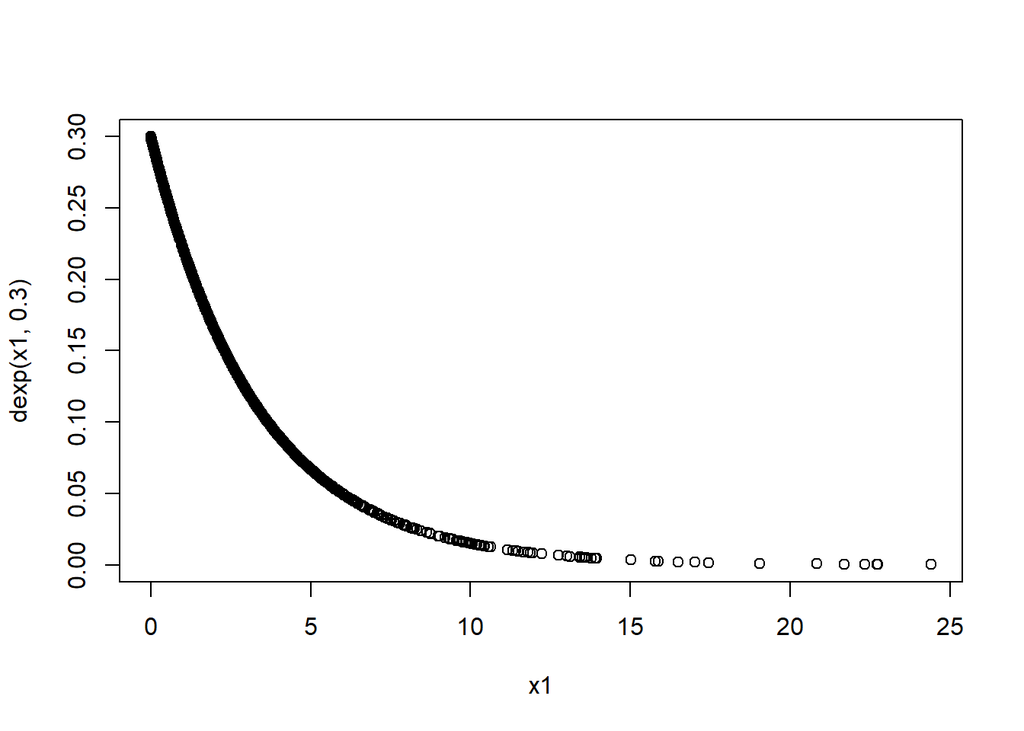

```r
x1<-rexp(1000, 0.3)
plot(x1, dexp(x1, 0.3), type='p')
```

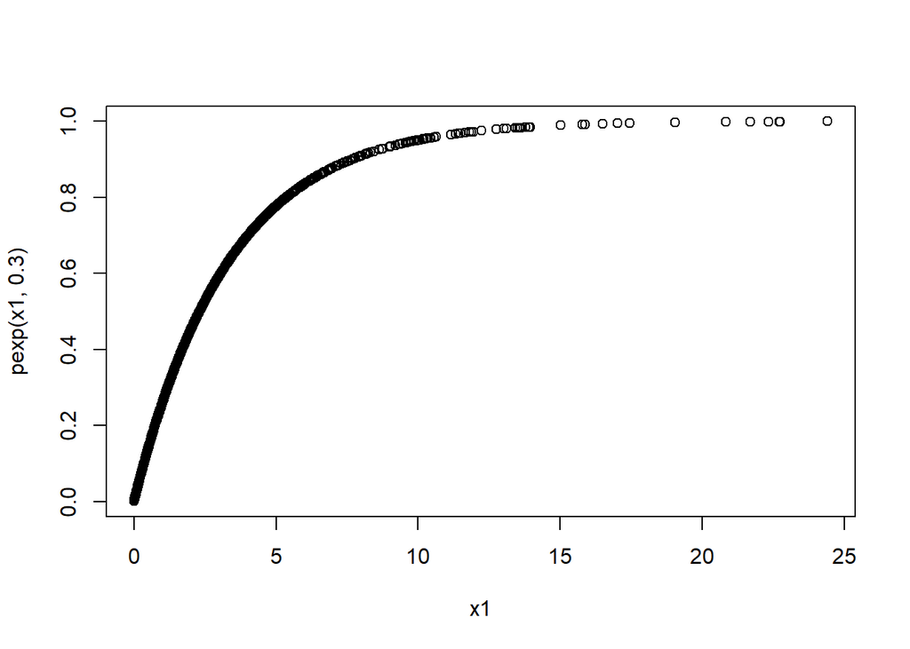

```r
plot(x1, pexp(x1, 0.3), type='p')
```

Критическое значение:

```r
qexp(0.99, 0.3)
```

```
## [1] 15.35057
```

Уровень доверия (0.5):

```r
pexp(1.38, 0.5)
```

```
## [1] 0.4984239
```

## Параметр λ = 3

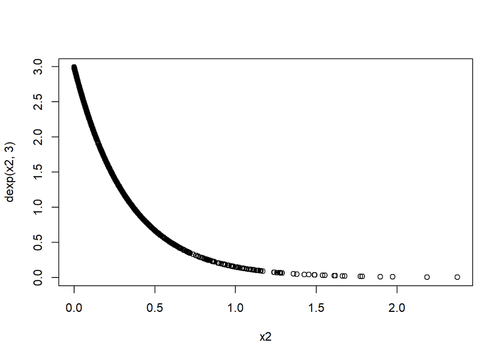

```r
x2<-rexp(1000, 3)
plot(x2, dexp(x2, 3), type='p')
```

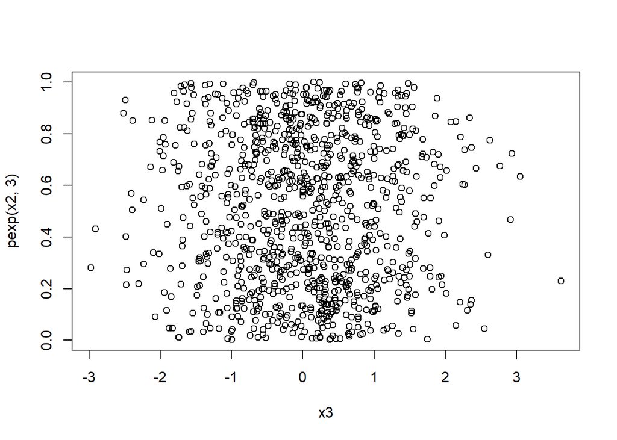

```r
plot(x3, pexp(x2, 3), type='p')
```

Критическое значение:

```r
qexp(0.95, 3)
```

```
## [1] 0.9985774
```

Уровень доверия (5):

```r
pexp(0.6, 5)
```

```
## [1] 0.9502129
```

## Параметр λ = 13

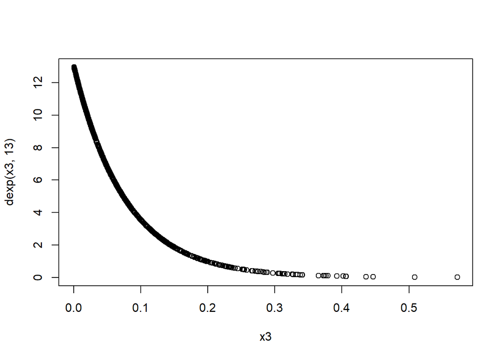

```r
x3<-rexp(1000, 13)
plot(x3, dexp(x3, 13), type='p')
```

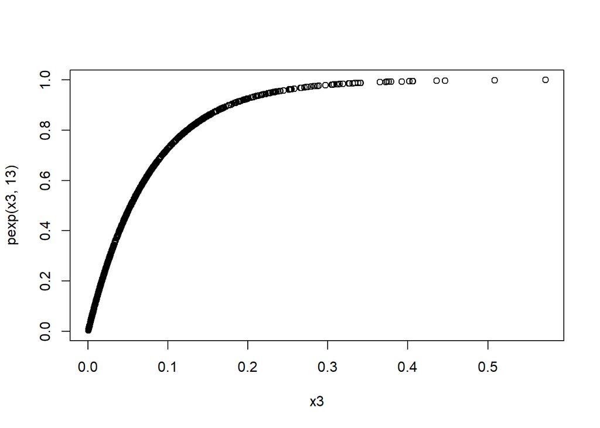

```r
plot(x3, pexp(x3, 13), type='p')
```

Критическое значение:

```r
qexp(0.90, 13)
```

```
## [1] 0.1771219
```

Уровень доверия (20):

```r
pexp(0.23, 20)
```

```
## [1] 0.9899482
```

## Параметр λ = 23

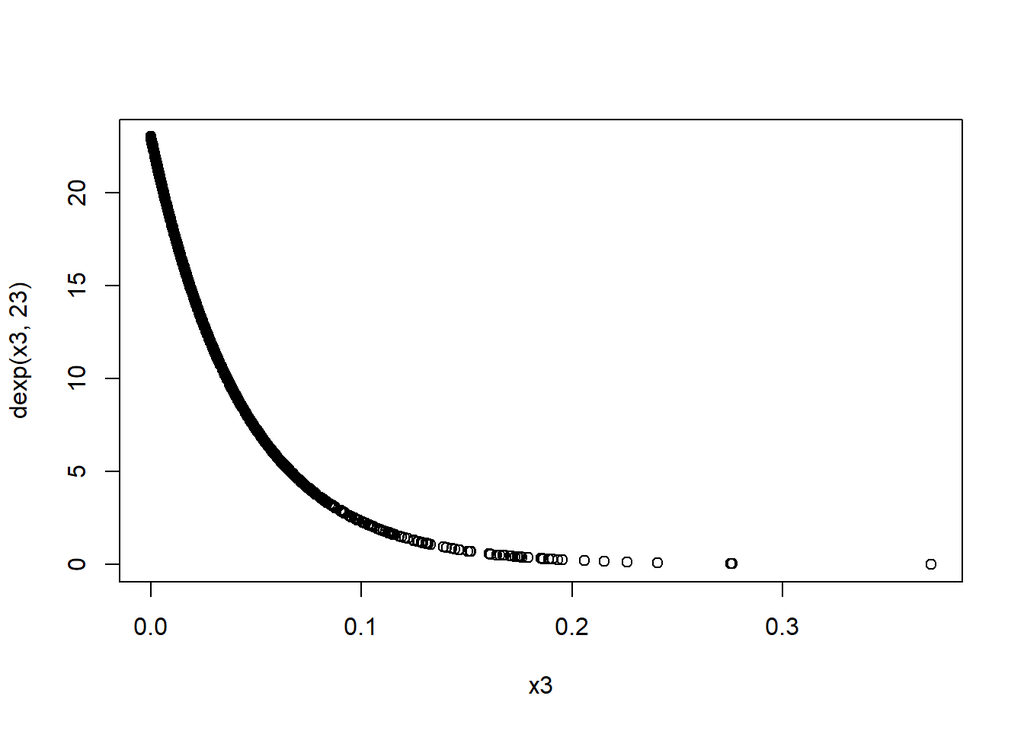

```r
x3<-rexp(1000, 23)
plot(x3, dexp(x3, 23), type='p')
```

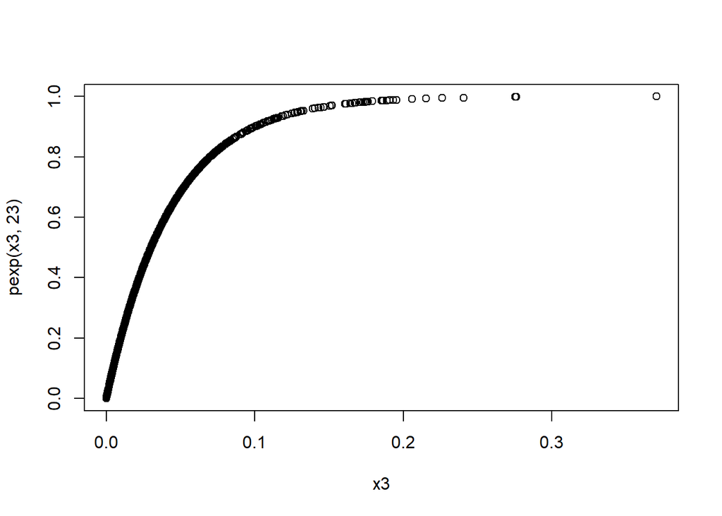

```r
plot(x3, pexp(x3, 23), type='p')
```

Критическое значение:

```r
qexp(0.90, 23)
```

```
## [1] 0.1001124
```

## Хи^2 распределения:

При увеличении числа степеней свободы кривая быстро смещается вправо, проявляя свойства симметрии, постепенно напоминая нормальное распределение.

## Степень свободы: df = 20

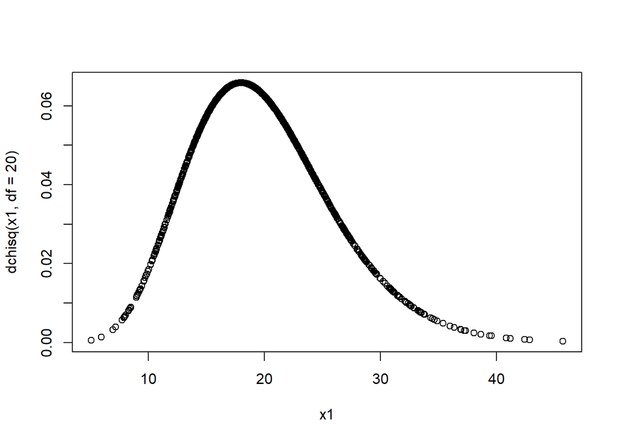

```r
x1<-rchisq(1000, 20)
plot(x1, dchisq(x1, df=20), type='p')
```

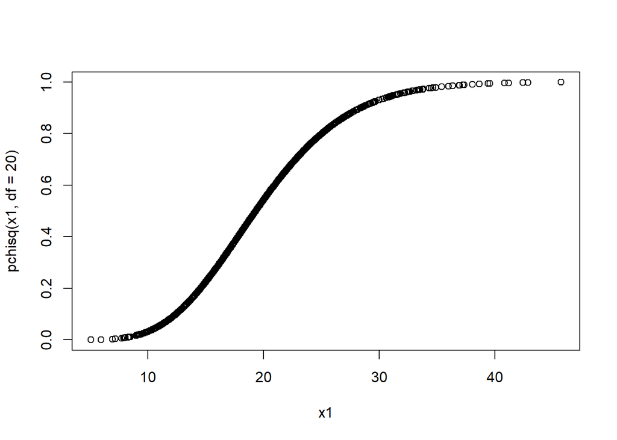

```r
plot(x1, pchisq(x1, df=20), type='p')
```

Критическое значение:

```r
qchisq(0.99, 20)
```

```
## [1] 37.56623
```

Уровень доверия (10):

```r
pchisq(12.54, 10)
```

```
## [1] 0.7494605
```

## Степень свободы: df= 50

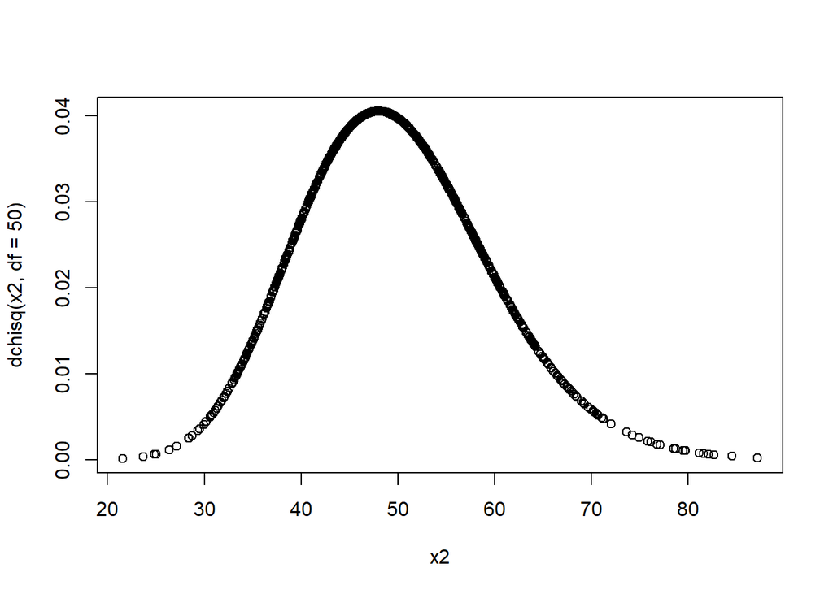

```r
x2<-rchisq(1000,  50)
plot(x2, dchisq(x2, df= 50), type='p')
```

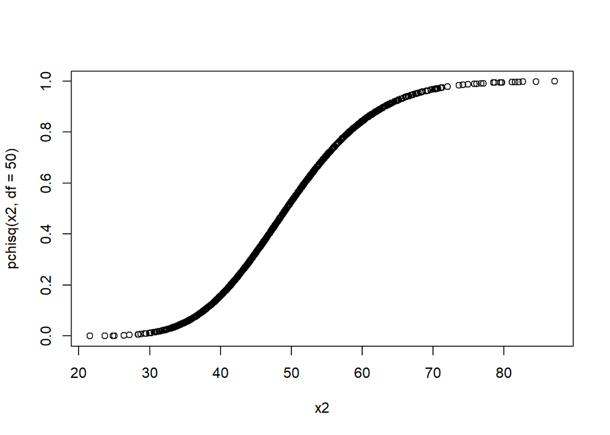

```r
plot(x2, pchisq(x2, df= 50), type='p')
```

Критическое значение:

```r
qchisq(0.95, 50)
```

```
## [1] 67.50481
```

Уровень доверия:

```r
pchisq(67.54, 50)
```

```
## [1] 0.9502968
```

## Степень свободы: df = 220

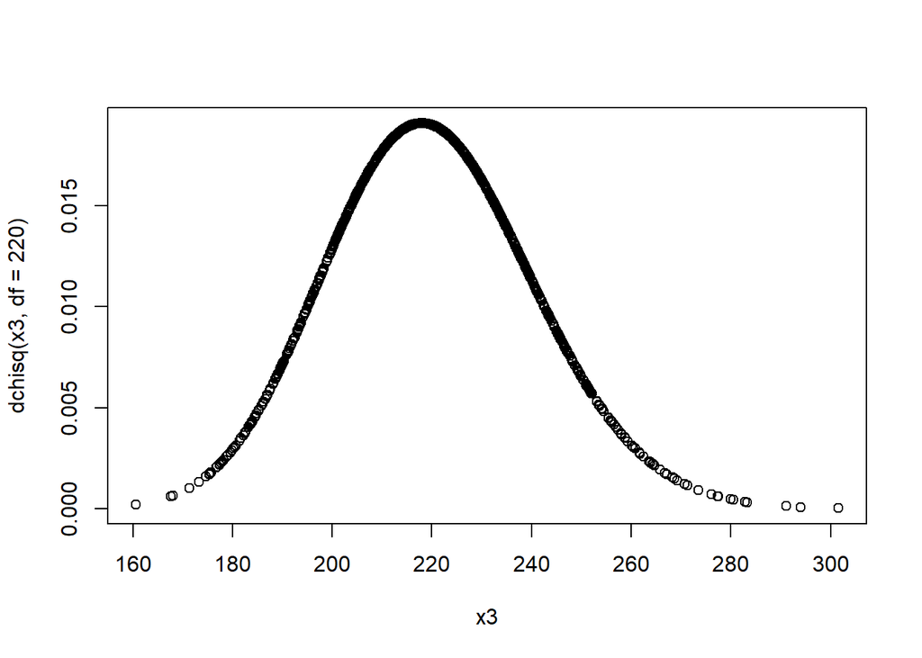

```r
x3<-rchisq(1000, 220)
plot(x3, dchisq(x3, df=220), type='p')
```

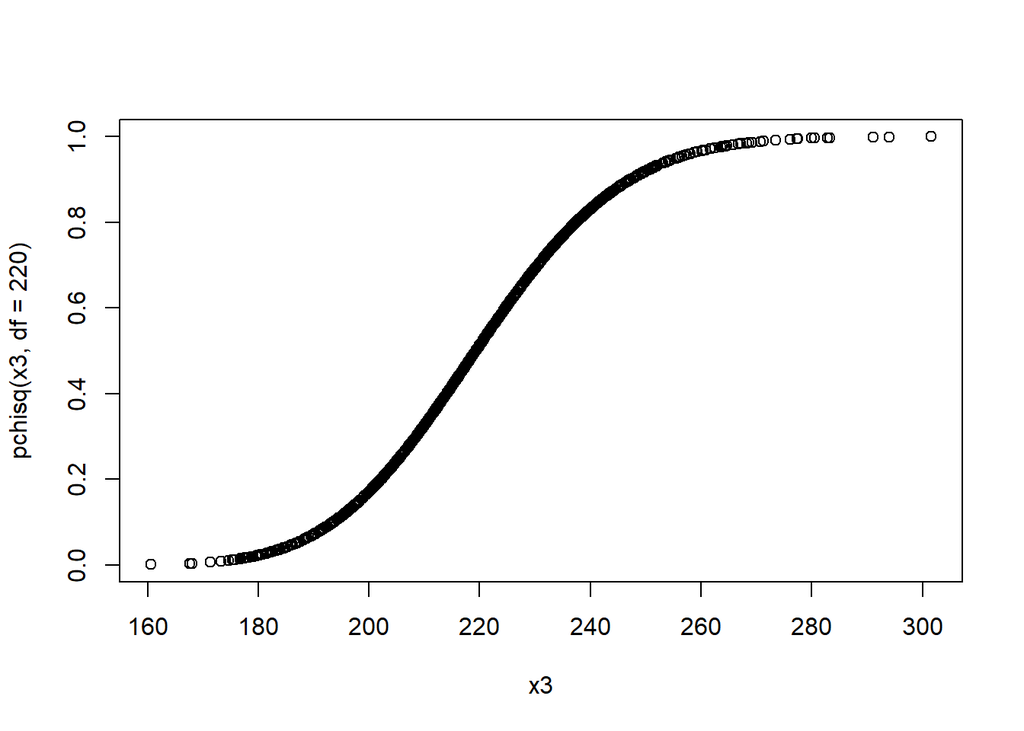

```r
plot(x3, pchisq(x3, df=220), type='p')
```

Критическое значение:

```r
qchisq(0.90, 220)
```

```
## [1] 247.2739
```

Уровень доверия:

```r
pchisq(200, 220)
```

```
## [1] 0.1705599
```